# Hummingbird Resource Specialization

Ben Weinstein

# 1 Aim

This is the master script that runs the data cleaning and baseline figures for the on going data collection at the Maquipucuna and Santa Lucia ecolodges.

# 2 Version Control

The first set of scripts are desciptive that clean, aggregate and quantify flowers, morphology, and hummingbird interactions.

# 3 Data Cleaning

Each hummingbird and plant sighting comes with a GPS tag for spatial mapping.

- These records need to be matched to the biodiversity data
- Remove duplicates
- Each data point should have a time stamp and elevation.

[figure not shown]

We measure corolla characteristics for each flower species along the elevation gradient. For this we need to:

- Clean taxonomy
- PCA of floral traits

# 4 Flowers Transects

Twice a month we census the number of available hummingbird floral resources along the elevation gradient.

- Taxonomic cleaning
- Mulitply number of stalks * inflorescences to estimate floral abundance
- Aggregate statistics on flowers/elevation over time

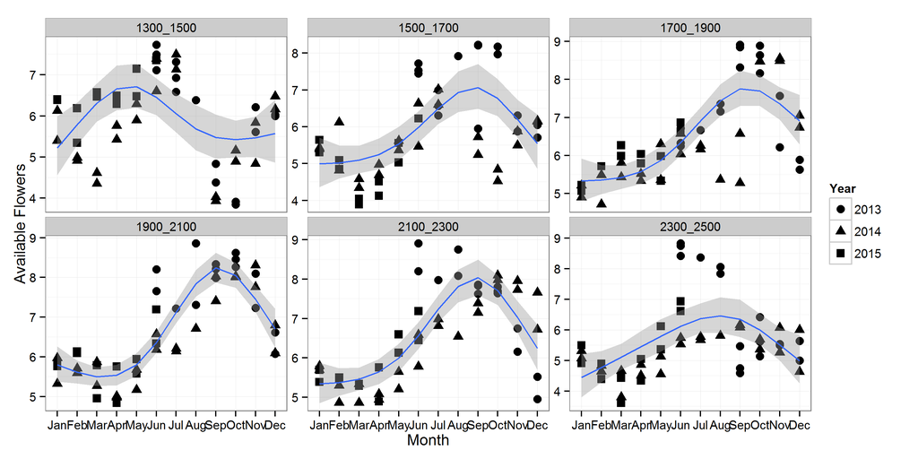

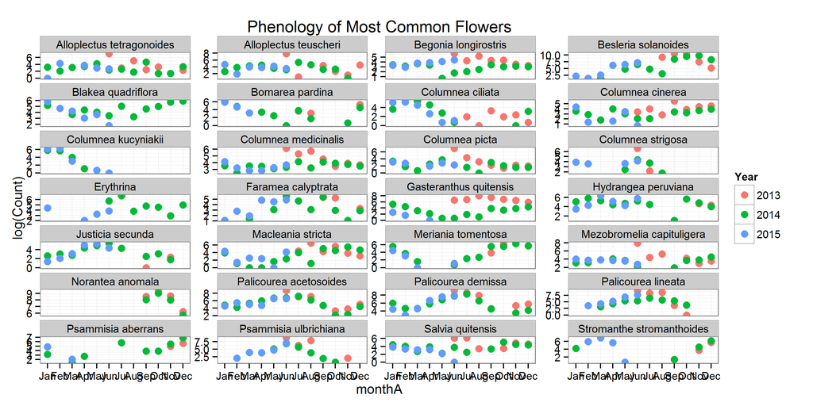

## 4.1 Plant Elevation ranges

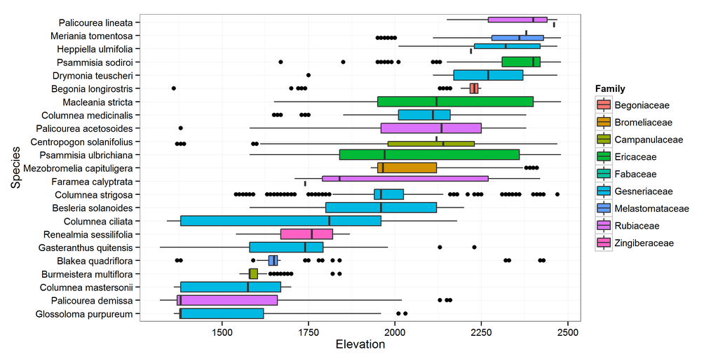

# 5 Hummingbird Transects

- Six elevation transects 2x/month to estimate hummingbird diversity and distribution

## 5.1 Hummingbird Morphology

To measure the bill lengths of each hummingbird species, as well as other foot and wing traits to associate with flower visitation and behavior.

## 5.2 Hummingbird Elevation Range

Plot hummingbird and flower distribution over space and time

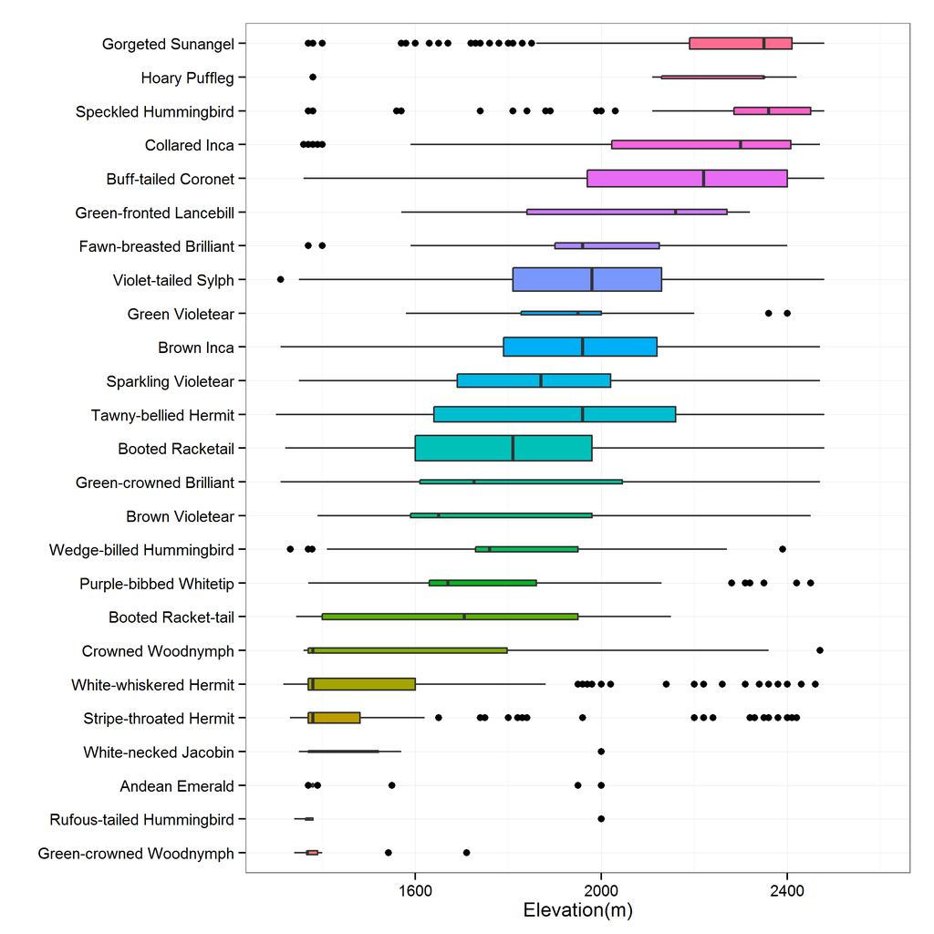

# 6 Sampling effort - Cameras.